# ETC5521 Worksheet 1

Introduction to exploratory data analysis

Author

Prof. Di Cook

## 🎯 Objectives

The goal of this worksheet is to tackle a data analysis together, by

- mapping out an analysis, with class input and help of AI
- work on cleaning a data set
- making some plots
- discussing what is surprising, and what is expected

## 📋 About the data

Only American citizens (and green-card holders) can contribute to federal politics, but the American divisions of foreign companies can form political action committees (PACs) and collect contributions from their American employees. This worksheet works with data on contributions to US political parties from foreign-connected PACs across 13 election cycles between 2000 and 2024, sourced from [OpenSecrets](https://www.opensecrets.org/political-action-committees-pacs/foreign-connected-pacs/2024).

We are going to take a look at [Mine Çetinkaya-Rundel’s keynote data analysis](https://speakerdeck.com/minecr/beyond-the-prompt-programming-as-a-pathway-to-statistical-thinking?slide=4) and work our way through the data analysis.

### Following the tutorial

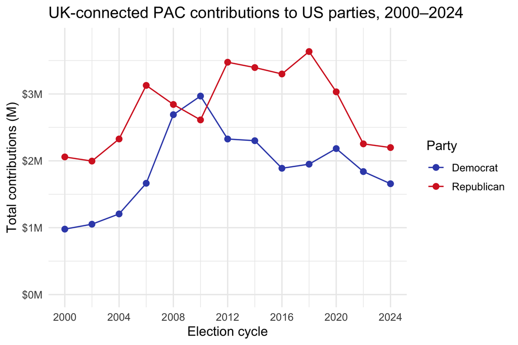

```r
load(here::here("data/pac_uk_long.rda"))
load(here::here("data/pac_uk_boot.rda"))
party_colours <- c(Democrat = "#3A4EB8", Republican = "#D62728")
pac_uk_long |>
  #group_by(year, party) |>
  #sample_n(size = n(), replace = TRUE) |>
  #ungroup() |>
  summarise(
    total_amount_M = sum(amount, na.rm = TRUE),
    .by = c(year, party)
  ) |>
  ggplot(aes(x=year,
             y=total_amount_M / 1e6,
             colour = party,
             group = party)) +
    geom_line() +
    geom_point(size = 2) +
    scale_colour_manual(values = party_colours) +
    scale_x_continuous(breaks = seq(2000, 2024, 4)) +
    scale_y_continuous(labels =
      scales::label_dollar(suffix = "M"), limits=c(0,3.8)) +
    labs(x = "Election cycle",
         y = "Total contributions (M)",
         colour = "Party",
         title = "UK-connected PAC contributions to US parties, 2000–2024") +
    theme_minimal()
```

### What happens with a different sample?

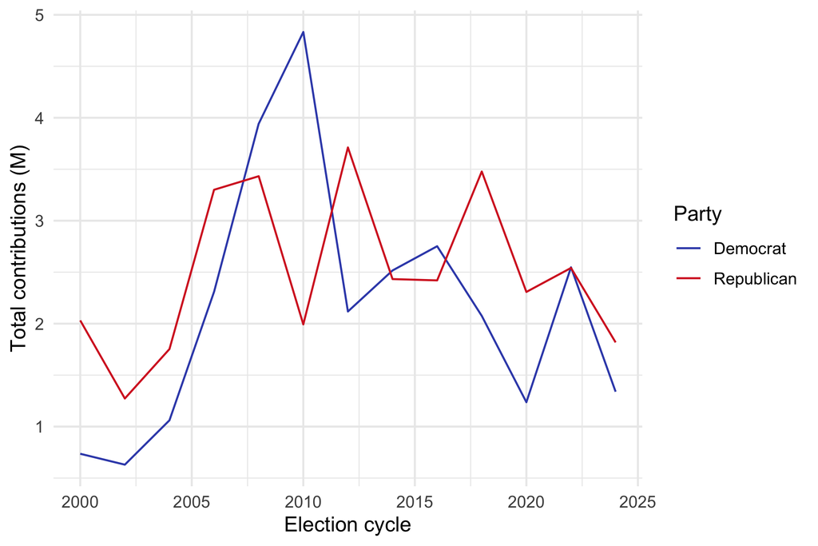

```r
pac_uk_long |>
  group_by(year, party) |>
  sample_n(size = n(), replace = TRUE) |>
  ungroup() |>
  summarise(
    total_amount_M = sum(amount, na.rm = TRUE),
    .by = c(year, party)
  ) |>
  ggplot(aes(x=year,
             y=total_amount_M/1e6,
             colour = party,
             group = party)) +
    geom_line() +
    scale_colour_manual(values = party_colours) +
    labs(x = "Election cycle",
         y = "Total contributions (M)",
         colour = "Party") +
    theme_minimal()
```

Repeat it multiple times. Why does the pattern change?

```r
library(ggdibbler)
B <- 20
ggplot(pac_uk_boot,
       aes(x = year, colour = party, group = party)) +
  geom_line_sample(
    aes(y = boot_dist),
    times = B, alpha = 0.2
  ) +
  geom_line(
    aes(y = total_amount_M),
    linewidth = 1
  ) +
  geom_point(aes(y = total_amount_M), size = 2) +
  scale_colour_manual(values = party_colours) +
  scale_x_continuous(breaks = seq(2000, 2024, 4)) +
  scale_y_continuous_distribution(labels = scales::label_dollar(suffix = "M")) +
  labs(
    x        = "Election cycle",
    y        = "Total contributions (M)",
    colour   = "Party"
  )
```

[output not shown]

### What happens each year?

```r
library(ggbeeswarm)
ggplot(pac_uk_long, aes(x=year, y=amount/1e6)) +
  geom_quasirandom() +
  facet_wrap(~party, ncol=1) +
  labs(x = "Election cycle",
       y = "Total contributions (M)",
       colour = "Party")
```

[output not shown]

Why do the totals vary so much when we sample the values for each party each year?

```r
ggplot(pac_uk_long, aes(x=party, y=amount/1e6)) +
  geom_quasirandom() +
  stat_summary(colour="red") +
  #scale_y_log10() +
  facet_wrap(~year, ncol=5) +
  coord_flip() +
  labs(x = "Election cycle",
       y = "Total contributions (M)",
       colour = "Party")
```

[output not shown]

### Where do donations come from?

```r
# Need to use brolgar
library(brolgar)
library(tsibble)
library(plotly)
set.seed(1024)
sampled_pacs <- pac_uk_long |>
  distinct(pac_name) |>
  slice_sample(n = 20) |>
  pull(pac_name)

pac_uk_long |>
  filter(pac_name %in% sampled_pacs) |>
  summarise(amount = sum(amount), .by = c(year, pac_name, party)) |>
  ggplot(aes(x=year,
             y=amount,
             group=pac_name,
             colour=party)) +
  geom_line(alpha = 0.7) +
  scale_colour_manual(values = party_colours) +
  facet_wrap(~party, ncol=1) +
  theme(legend.position = "none")
ggplotly()
```

[output not shown]

### Do the same donors donate every year?

### Do donors favor one party?

```r
library(forcats)
set.seed(1024)
sampled_pacs <- pac_uk_long |>
  distinct(pac_name) |>
  slice_sample(n = 10) |>
  pull(pac_name)
pac_uk_long |>
  filter(pac_name %in% sampled_pacs) |>
  mutate(party = fct_recode(party, D="Democrat", R="Republican")) |>
  summarise(amount = sum(amount), .by = c(year, pac_name, party)) |>
  ggplot(aes(x=party,
             y=amount,
             group=pac_name)) +
  geom_point() +
  geom_line(alpha = 0.7) +
  facet_grid(pac_name~year) +
  theme(legend.position = "none")
ggplotly()
```

[output not shown]